# Workshop 5

Kaysha Kenney

2023-05-10

# Load into R library

```r
library(tidyverse)
library(sf) # simple features
library (terra) # for raster
```

```
## terra 1.7.29
##
##
```

```r
library(tmap) # Thematic maps are geographical maps in which spatial data distributions are visualized
```

# Upload copepod data set. Took the folder from my desktop and put it in my GitHub folder and into R and into my end to end analysis folder so the data set in now in my R, which I can then upload.

```r
library(readr)
dat <- read_csv("data-for-course/copepods_raw.csv")
dat
```

```
## # A tibble: 5,313 × 11
##    silk_id segment_no latitude longitude sample_time_utc  project route vessel
##      <dbl>      <dbl>    <dbl>     <dbl> <chr>            <chr>   <chr> <chr>
##  1       1          1    -28.3      154. 26/06/2009 22:08 AusCPR  BRSY  ANL Win…
##  2       1          5    -28.7      154. 26/06/2009 23:12 AusCPR  BRSY  ANL Win…
##  3       1          9    -29.0      154. 27/06/2009 0:17  AusCPR  BRSY  ANL Win…
##  4       1         13    -29.3      154. 27/06/2009 1:22  AusCPR  BRSY  ANL Win…
##  5       1         17    -29.7      154. 27/06/2009 2:26  AusCPR  BRSY  ANL Win…
##  6       1         18    -29.8      154. 27/06/2009 2:43  AusCPR  BRSY  ANL Win…
##  7       1         26    -30.4      153. 27/06/2009 4:52  AusCPR  BRSY  ANL Win…
##  8       1         30    -30.7      153. 27/06/2009 5:57  AusCPR  BRSY  ANL Win…
##  9       1         33    -31.0      153. 27/06/2009 6:45  AusCPR  BRSY  ANL Win…
## 10       1         37    -31.3      153. 27/06/2009 7:50  AusCPR  BRSY  ANL Win…
## # ℹ 5,303 more rows
## # ℹ 3 more variables: meanlong <dbl>, region <chr>, richness_raw <dbl>
```

# 6.7.1 Check coordinates

# First we need to make a ggplot to plot the coordinates for the samples

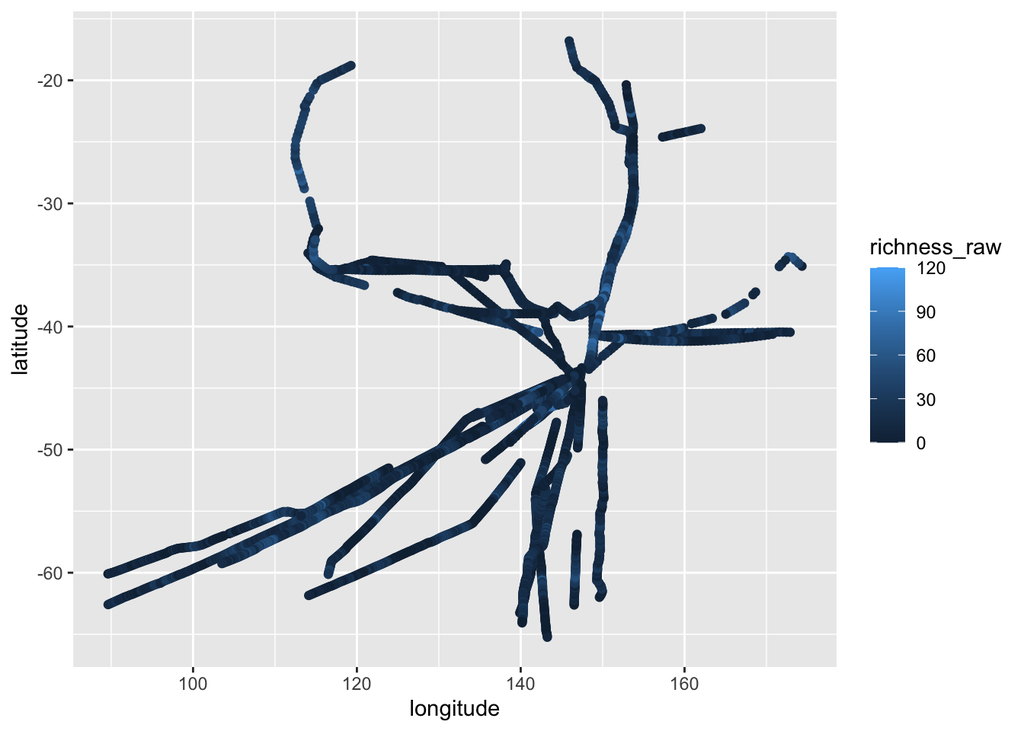

```r
library(ggplot2)
ggplot(dat) +
  aes(x = longitude, y = latitude, color = richness_raw) +
  geom_point()
```

# Look at the richness data (main variable). Visualize richness in non-spatial way with latitue on the x axis and richness on the y axis.

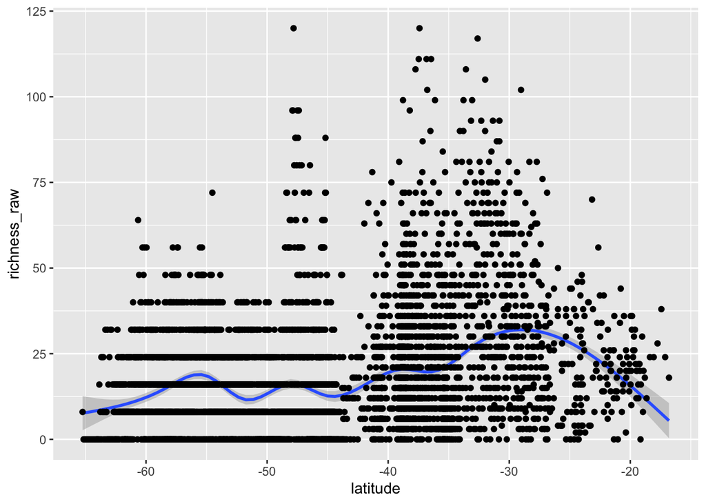

```r
ggplot(dat, aes(x = latitude, y = richness_raw)) +
  stat_smooth() +
  geom_point()
```

# 6.8 Getting going with maps

# repeat the same richness but with packages for GIS and mapping. Turn data into ‘simple features collection’

```r
sdat <- st_as_sf(dat, coords = c("longitude", "latitude"),
                 crs = 4326)
```

# 6.9 Coordinate Reference Systems

```r
crs4326 <- st_crs(4326)
crs4326 # look at the whole CRS
```

```
## Coordinate Reference System:
##   User input: EPSG:4326
##   wkt:
## GEOGCRS["WGS 84",
##     ENSEMBLE["World Geodetic System 1984 ensemble",
##         MEMBER["World Geodetic System 1984 (Transit)"],
##         MEMBER["World Geodetic System 1984 (G730)"],
##         MEMBER["World Geodetic System 1984 (G873)"],
##         MEMBER["World Geodetic System 1984 (G1150)"],
##         MEMBER["World Geodetic System 1984 (G1674)"],
##         MEMBER["World Geodetic System 1984 (G1762)"],
##         MEMBER["World Geodetic System 1984 (G2139)"],
##         ELLIPSOID["WGS 84",6378137,298.257223563,
##             LENGTHUNIT["metre",1]],
##         ENSEMBLEACCURACY[2.0]],
##     PRIMEM["Greenwich",0,
##         ANGLEUNIT["degree",0.0174532925199433]],
##     CS[ellipsoidal,2],
##         AXIS["geodetic latitude (Lat)",north,
##             ORDER[1],
##             ANGLEUNIT["degree",0.0174532925199433]],
##         AXIS["geodetic longitude (Lon)",east,
##             ORDER[2],
##             ANGLEUNIT["degree",0.0174532925199433]],
##     USAGE[
##         SCOPE["Horizontal component of 3D system."],
##         AREA["World."],
##         BBOX[-90,-180,90,180]],
##     ID["EPSG",4326]]
```

```r
crs4326$Name # pull out just the name of the crs
```

```
## [1] "WGS 84"
```

```r
crs4326$wkt # crs in well-known text format
```

```
## [1] "GEOGCRS[\"WGS 84\",\n    ENSEMBLE[\"World Geodetic System 1984 ensemble\",\n        MEMBER[\"World Geodetic System 1984 (Transit)\"],\n        MEMBER[\"World Geodetic System 1984 (G730)\"],\n        MEMBER[\"World Geodetic System 1984 (G873)\"],\n        MEMBER[\"World Geodetic System 1984 (…
```

# 6.10 Feature Collection

```r
sdat
```

```
## Simple feature collection with 5313 features and 9 fields
## Geometry type: POINT
## Dimension:     XY
## Bounding box:  xmin: 89.6107 ymin: -65.2428 xmax: 174.335 ymax: -16.80253
## Geodetic CRS:  WGS 84
## # A tibble: 5,313 × 10
##    silk_id segment_no sample_time_utc  project route vessel      meanlong region
##  *   <dbl>      <dbl> <chr>            <chr>   <chr> <chr>          <dbl> <chr>
##  1       1          1 26/06/2009 22:08 AusCPR  BRSY  ANL Windar…     153. East
##  2       1          5 26/06/2009 23:12 AusCPR  BRSY  ANL Windar…     153. East
##  3       1          9 27/06/2009 0:17  AusCPR  BRSY  ANL Windar…     153. East
##  4       1         13 27/06/2009 1:22  AusCPR  BRSY  ANL Windar…     153. East
##  5       1         17 27/06/2009 2:26  AusCPR  BRSY  ANL Windar…     153. East
##  6       1         18 27/06/2009 2:43  AusCPR  BRSY  ANL Windar…     153. East
##  7       1         26 27/06/2009 4:52  AusCPR  BRSY  ANL Windar…     153. East
##  8       1         30 27/06/2009 5:57  AusCPR  BRSY  ANL Windar…     153. East
##  9       1         33 27/06/2009 6:45  AusCPR  BRSY  ANL Windar…     153. East
## 10       1         37 27/06/2009 7:50  AusCPR  BRSY  ANL Windar…     153. East
## # ℹ 5,303 more rows
## # ℹ 2 more variables: richness_raw <dbl>, geometry <POINT [°]>
```

# 6.11 Cartography

# Mapping, only plotting the richness column.

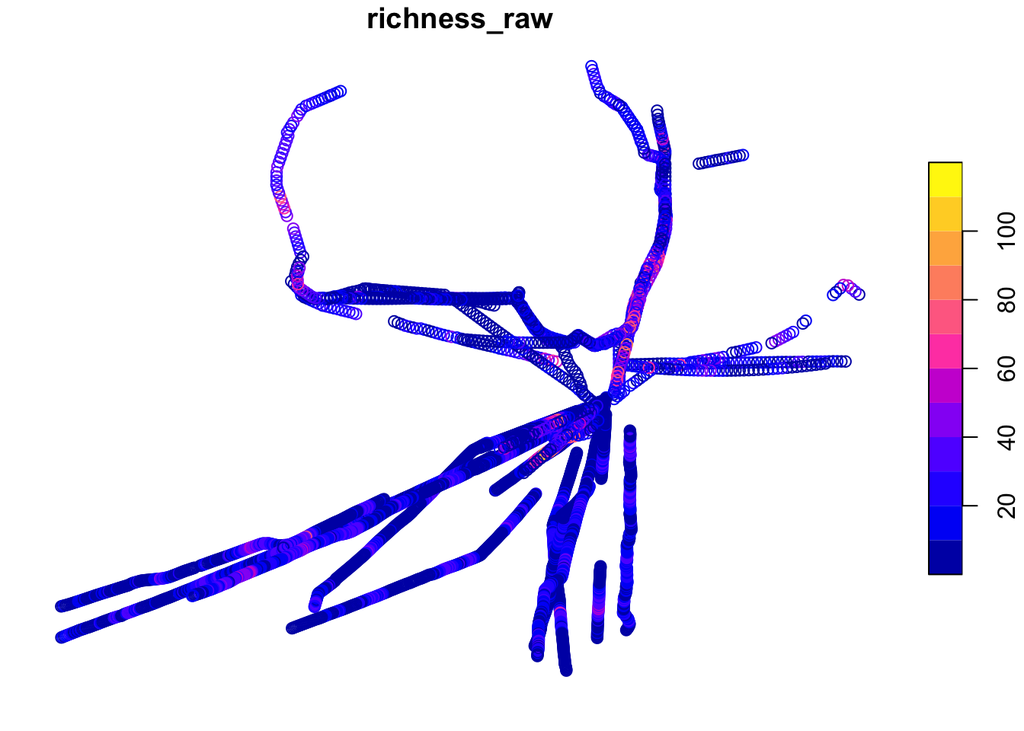

```r
plot(sdat["richness_raw"])
```

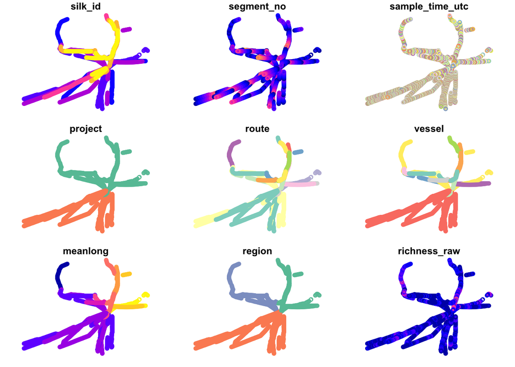

```r
plot(sdat)
```

# 6.12 Thematic maps for communication

# Going to build and add on layers

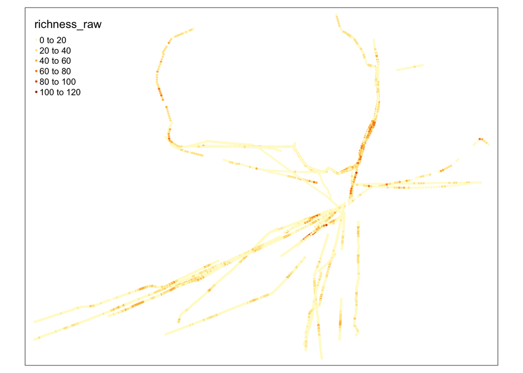

```r
#using tmap
tm1 <- tm_shape(sdat) +
  tm_dots(col = "richness_raw")
tm1
```

# Save the map to the working directory. Make sure to change the output path if I need to save it to a different folder

```r
tmap_save(tm1, filename = "Richness-map.png",
          width = 600, height = 600)
```

```
## Map saved to /Users/kayshakenney/Desktop/Kaysha GitHub/R/End to End Analysis/Richness-map.png
```

```
## Resolution: 600 by 600 pixels
```

```
## Size: 2 by 2 inches (300 dpi)
```

# 6.13 Mapping spatial polygons as layers

# Read the shapefiles directly into R with the st_read comman, similar to read_csv but for spatial files

```r
aus <- st_read("data-for-course/spatial-data/Aussie/Aussie.shp")
shelf <- st_read("data-for-course/spatial-data/aus_shelf/aus_shelf.shp")
regions <- st_read("data-for-course/spatial-data/regions/regions.shp")
aus
```

```
## Simple feature collection with 8 features and 1 field
## Geometry type: MULTIPOLYGON
## Dimension:     XY
## Bounding box:  xmin: 112.9211 ymin: -43.63192 xmax: 153.6389 ymax: -9.229614
## Geodetic CRS:  WGS 84
##   adm                       geometry
## 1 NSW MULTIPOLYGON (((141.0029 -3...
## 2 Vic MULTIPOLYGON (((140.9659 -3...
## 3 QLD MULTIPOLYGON (((153.5522 -2...
## 4  SA MULTIPOLYGON (((129.0013 -2...
## 5  WA MULTIPOLYGON (((129.0012 -1...
## 6 Tas MULTIPOLYGON (((148.3096 -4...
## 7  NT MULTIPOLYGON (((137.9962 -1...
## 8 ACT MULTIPOLYGON (((149.1253 -3...
```

# 6.13.12 Mapping your polygons

# Making a map of polygons

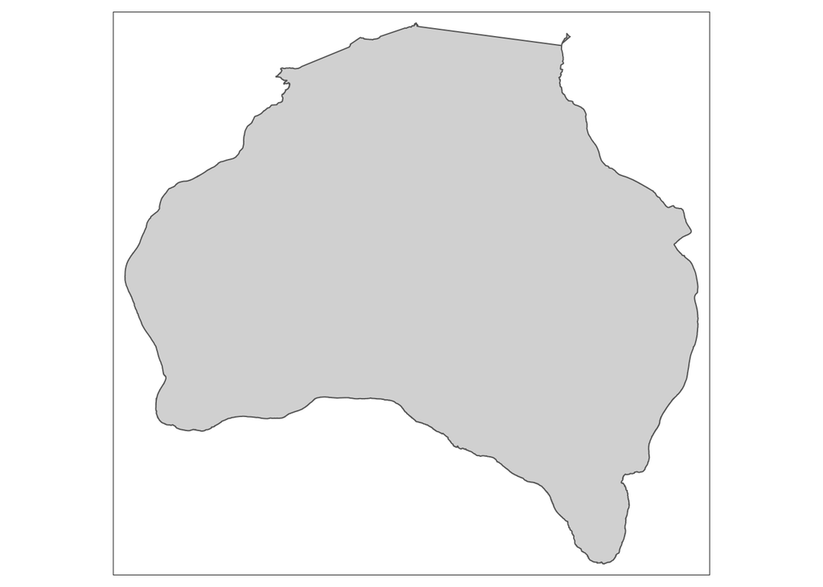

```r
tm_shape(shelf) +
  tm_polygons()
```

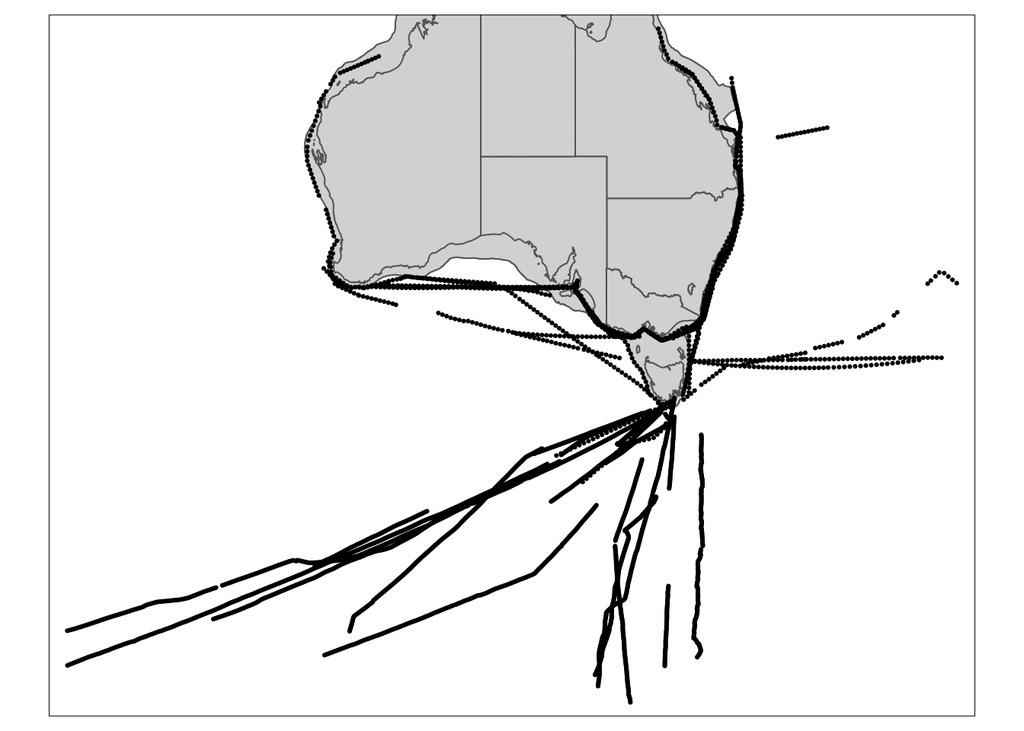

```r
tm_shape(shelf, bbox = sdat) +
  tm_polygons() +
  tm_shape(aus) +
  tm_polygons() +
  tm_shape(sdat) +
  tm_dots()
```

# 6.14 Exploring t_map

# Changing the style of the map, similar to ggplot themes function, allows us to customize it

```r
vignette('tmap-getstarted')
```

```
## starting httpd help server ... done
```

# Customizing the Australia map

```r
tm2 <- tm_shape(regions) +
  tm_polygons(col = "region", palette = "magma") +
  tm_shape(shelf, bbox = sdat) +
  tm_polygons() +
  tm_shape(aus) +
  tm_polygons(col = "adm") +
  tm_shape(sdat) +
  tm_dots(col = "richness_raw")+
  tmap_style("natural")
```

```
## tmap style set to "natural"
```

```
## other available styles are: "white", "gray", "cobalt", "col_blind", "albatross", "beaver", "bw", "classic", "watercolor"
```

```r
tm_shape(regions) +
  tm_polygons(col = "region", palette = "magma") +
  tm_shape(shelf, bbox = sdat) +
  tm_polygons() +
  tm_shape(aus) +
  tm_polygons(col = "adm") +
  tm_shape(sdat) +
  tm_dots(col = "richness_raw")+
  tmap_style("natural")
```

```
## tmap style set to "natural"
```

```
## other available styles are: "white", "gray", "cobalt", "col_blind", "albatross", "beaver", "bw", "classic", "watercolor"
```

[figure not shown]

# save the new customized map

```r
tmap_save(tm2, filename = "Richness-map.png",
          width = 600, height = 600)
```

```
## Map saved to /Users/kayshakenney/Desktop/Kaysha GitHub/R/End to End Analysis/Richness-map.png
```

```
## Resolution: 600 by 600 pixels
```

```
## Size: 2 by 2 inches (300 dpi)
```